# Parcial1

| **Nombre del estudiante** | *Ian Morales* |
| --- | --- |
| **Fecha de entrega** | *30/09/2026* |
| **Asignatura** | Machine Learning 2 |
| **Carrera / Nivel** | Desarrollo de Software · Segundo |
| **Docente** | Msc. Elvis Pachacama (c) |

## Objetivo

Desarrollar un proceso completo de Machine Learning que construya un modelo de regresión lineal múltiple capaz de estimar los gastos médicos (`charges`) a partir de las características de cada persona (edad, sexo, BMI, dependientes, condición de fumador y región), cubriendo desde la carga de datos hasta la predicción de nuevas observaciones.

## Descripción del caso

Una organización de servicios de salud quiere saber qué características se asocian con costos médicos más altos y contar con un modelo que estime charges para personas nuevas. El dataset (Kaggle, Medical Cost Personal Datasets) tiene 1 338 registros y 7 columnas.

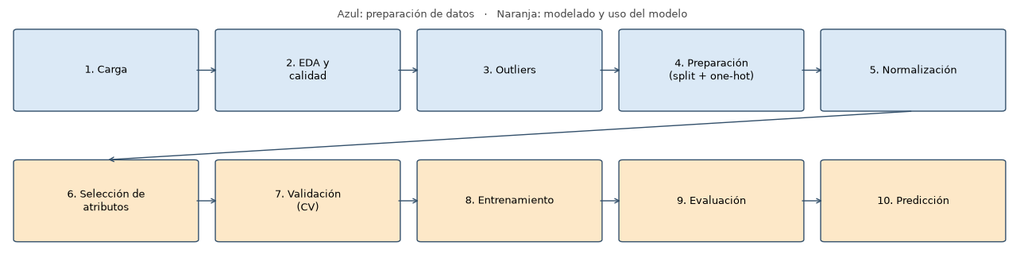

```python
# Diagrama del flujo del proyecto
import matplotlib.pyplot as plt
from matplotlib.patches import FancyBboxPatch

fases = ["1. Carga", "2. EDA y\ncalidad", "3. Outliers", "4. Preparación\n(split + one-hot)", "5. Normalización",
         "6. Selección de\natributos", "7. Validación\n(CV)", "8. Entrenamiento", "9. Evaluación", "10. Predicción"]

fig, ax = plt.subplots(figsize=(13, 3.6))
ax.set_xlim(0, 5.4); ax.set_ylim(0, 2.2); ax.axis("off")

posiciones = []
for i, texto in enumerate(fases):
    fila, col = divmod(i, 5)
    x = col * 1.08 + 0.05
    y = 1.35 if fila == 0 else 0.25
    if fila == 1:                      # segunda fila va de izquierda a derecha también
        x = col * 1.08 + 0.05
    color = "#dbe9f6" if i < 5 else "#fde8c8"
    ax.add_patch(FancyBboxPatch((x, y), 0.95, 0.65, boxstyle="round,pad=0.02", fc=color, ec="#33506b"))
    ax.text(x + 0.475, y + 0.325, texto, ha="center", va="center", fontsize=9)
    posiciones.append((x, y))

for i in range(9):
    (x1, y1), (x2, y2) = posiciones[i], posiciones[i + 1]
    if i == 4:                         # salto de fila
        ax.annotate("", xy=(x2 + 0.475, y2 + 0.67), xytext=(x1 + 0.475, y1 - 0.02),
                    arrowprops=dict(arrowstyle="->", color="#33506b", connectionstyle="arc3,rad=0.0"))
    else:
        ax.annotate("", xy=(x2, y2 + 0.325), xytext=(x1 + 0.95, y1 + 0.325),
                    arrowprops=dict(arrowstyle="->", color="#33506b"))

ax.text(2.7, 2.12, "Azul: preparación de datos   ·   Naranja: modelado y uso del modelo", ha="center", fontsize=9, color="#444")
plt.tight_layout(); plt.show()
```

## Librerías y configuración

- **pandas / numpy**: manejo de tablas y cálculo numérico.
- **matplotlib / seaborn**: gráficas del análisis exploratorio y de la evaluación.
- **scipy.stats**: utilidades estadísticas (asimetría).
- **scikit-learn**: todo el flujo de modelado (`Pipeline`, `ColumnTransformer`, `StandardScaler`, `OneHotEncoder`, `SelectKBest`, `KFold`, `GridSearchCV`, `LinearRegression`, métricas).
- **kagglehub**: descarga automática del dataset desde Kaggle.

Se fija una **semilla (`SEED = 42`)** para que cualquier persona que ejecute el notebook obtenga exactamente los mismos resultados.

```python
import os, sys, shutil, subprocess, warnings
import numpy as np
import pandas as pd
import matplotlib.pyplot as plt
import seaborn as sns
from scipy import stats

from sklearn.model_selection import train_test_split, KFold, GridSearchCV, cross_validate
from sklearn.pipeline import Pipeline
from sklearn.compose import ColumnTransformer
from sklearn.impute import SimpleImputer
from sklearn.preprocessing import StandardScaler, OneHotEncoder
from sklearn.feature_selection import SelectKBest, f_regression, mutual_info_regression
from sklearn.linear_model import LinearRegression
from sklearn.dummy import DummyRegressor
from sklearn.base import clone
from sklearn.metrics import mean_absolute_error, mean_squared_error, r2_score

warnings.filterwarnings("ignore")
sns.set_theme(style="whitegrid", palette="deep")
pd.set_option("display.float_format", lambda v: f"{v:,.2f}")

SEED = 42
```

# Fase 1. Carga y comprensión de los datos (10 %)

**Objetivo.** Traer el dataset de forma automática y entender qué contiene cada columna antes de tocar nada.

**Procedimiento.**

1. La función `obtener_dataset()` usa `kagglehub.dataset_download("mirichoi0218/insurance")` para bajar el archivo desde Kaggle y lo copia a la carpeta `dataset/`. Si no hay conexión o credenciales, busca una copia local (`dataset/insurance.csv` o `insurance.csv`) para que el notebook no se rompa.
2. `pd.read_csv` carga el archivo en un DataFrame.
3. `shape`, `head()`, `info()` y `describe()` muestran tamaño, primeras filas, tipos de dato y resumen estadístico.

**Justificación.** Automatizar la descarga hace el trabajo reproducible (cualquiera lo ejecuta sin bajar archivos a mano) y la inspección inicial evita construir un modelo sobre datos mal leídos.

**Diccionario de datos**

| Variable | Tipo | Descripción |
| --- | --- | --- |
| `age` | numérica (entera) | Edad del titular (años) |
| `sex` | categórica | Sexo: `female` / `male` |
| `bmi` | numérica (continua) | Índice de masa corporal (kg/m²) |
| `children` | numérica (entera) | Número de dependientes cubiertos |
| `smoker` | categórica | ¿Fuma? `yes` / `no` |
| `region` | categórica | Región residencial en EE. UU.: `northeast`, `northwest`, `southeast`, `southwest` |
| `charges` | numérica (continua) | **Variable objetivo**: gastos médicos facturados (USD) |

```python
def obtener_dataset(slug="mirichoi0218/insurance", archivo="insurance.csv", destino="dataset"):
    """Descarga el dataset desde Kaggle (kagglehub). Si falla, usa una copia local."""
    os.makedirs(destino, exist_ok=True)
    ruta_destino = os.path.join(destino, archivo)
    try:
        try:
            import kagglehub
        except ImportError:
            subprocess.check_call([sys.executable, "-m", "pip", "install", "-q", "kagglehub"])
            import kagglehub
        carpeta = kagglehub.dataset_download(slug)           # descarga (o toma la caché de kagglehub)
        shutil.copy(os.path.join(carpeta, archivo), ruta_destino)
        print(f"Descargado desde Kaggle -> {ruta_destino}")
    except Exception as error:
        print(f"No se pudo descargar desde Kaggle ({type(error).__name__}). Se buscará una copia local.")
        for candidato in (ruta_destino, archivo):
            if os.path.exists(candidato):
                ruta_destino = candidato
                break
        else:
            raise FileNotFoundError("No hay copia local de insurance.csv.") from error
    return ruta_destino

ruta = obtener_dataset()
df = pd.read_csv(ruta)
print(f"Archivo en uso: {ruta}")
print(f"Dimensión: {df.shape[0]} filas x {df.shape[1]} columnas")
df.head()
```

```
Downloading to C:\Users\USUARIO\.cache\kagglehub\datasets\mirichoi0218\insurance\1.archive...
```

```
Extracting files...
Descargado desde Kaggle -> dataset\insurance.csv
Archivo en uso: dataset\insurance.csv
Dimensión: 1338 filas x 7 columnas
```

|  | age | sex | bmi | children | smoker | region | charges |
| --- | --- | --- | --- | --- | --- | --- | --- |
| 0 | 19 | female | 27.90 | 0 | yes | southwest | 16,884.92 |
| 1 | 18 | male | 33.77 | 1 | no | southeast | 1,725.55 |
| 2 | 28 | male | 33.00 | 3 | no | southeast | 4,449.46 |
| 3 | 33 | male | 22.70 | 0 | no | northwest | 21,984.47 |
| 4 | 32 | male | 28.88 | 0 | no | northwest | 3,866.86 |

```python
df.info()
```

```
<class 'pandas.DataFrame'>
RangeIndex: 1338 entries, 0 to 1337
Data columns (total 7 columns):
 #   Column    Non-Null Count  Dtype
---  ------    --------------  -----
 0   age       1338 non-null   int64
 1   sex       1338 non-null   str
 2   bmi       1338 non-null   float64
 3   children  1338 non-null   int64
 4   smoker    1338 non-null   str
 5   region    1338 non-null   str
 6   charges   1338 non-null   float64
dtypes: float64(2), int64(2), str(3)
memory usage: 73.3 KB
```

```python
# Resumen de numéricas y de categóricas
display(df.describe())
display(df.describe(include="object"))
```

|  | age | bmi | children | charges |
| --- | --- | --- | --- | --- |
| count | 1,338.00 | 1,338.00 | 1,338.00 | 1,338.00 |
| mean | 39.21 | 30.66 | 1.09 | 13,270.42 |
| std | 14.05 | 6.10 | 1.21 | 12,110.01 |
| min | 18.00 | 15.96 | 0.00 | 1,121.87 |
| 25% | 27.00 | 26.30 | 0.00 | 4,740.29 |
| 50% | 39.00 | 30.40 | 1.00 | 9,382.03 |
| 75% | 51.00 | 34.69 | 2.00 | 16,639.91 |
| max | 64.00 | 53.13 | 5.00 | 63,770.43 |

|  | sex | smoker | region |
| --- | --- | --- | --- |
| count | 1338 | 1338 | 1338 |
| unique | 2 | 2 | 4 |
| top | male | no | southeast |
| freq | 676 | 1064 | 364 |

**Lectura de resultados.** El dataset tiene 1 338 registros y 7 columnas: 4 numéricas (`age`, `bmi`, `children`, `charges`) y 3 categóricas (`sex`, `smoker`, `region`). La edad va de 18 a 64 años y el BMI tiene una media cercana a 30 (rango de sobrepeso/obesidad). Se nota que la media de `charges` es bastante mayor que su mediana, una primera señal de distribución sesgada que se confirma en la Fase 2.

# Fase 2. EDA y calidad de los datos (15 %)

**Objetivo.** Verificar que los datos son confiables (sin vacíos ni repetidos) y descubrir qué variables se relacionan con `charges`.

**Procedimiento.**

1. **Calidad:** conteo de nulos (`isna().sum()`), duplicados (`duplicated()`), tipos de dato y valores únicos de cada categórica (detecta errores de digitación como `Male` vs `male`).
2. **Distribución de la variable objetivo:** histograma de `charges` y su asimetría (*skewness*).
3. **Variables categóricas:** conteo por categoría y distribución de `charges` en cada una.
4. **Relaciones numéricas:** dispersión contra `charges` y matriz de correlación de Pearson.

**Justificación.** Un modelo lineal asume datos completos y numéricos; además, el EDA orienta las decisiones de las fases siguientes (outliers, transformaciones, selección).

```python
# --- 2.1 Calidad de datos ---
calidad = pd.DataFrame({
    "tipo": df.dtypes.astype(str),
    "nulos": df.isna().sum(),
    "% nulos": df.isna().mean() * 100,
    "valores únicos": df.nunique(),
})
display(calidad)

n_dup = df.duplicated().sum()
print(f"Filas duplicadas: {n_dup}")
display(df[df.duplicated(keep=False)])

print("\nCategorías encontradas:")
for col in ["sex", "smoker", "region"]:
    print(f"  {col}: {sorted(df[col].unique())}")
```

|  | tipo | nulos | % nulos | valores únicos |
| --- | --- | --- | --- | --- |
| age | int64 | 0 | 0.00 | 47 |
| sex | str | 0 | 0.00 | 2 |
| bmi | float64 | 0 | 0.00 | 548 |
| children | int64 | 0 | 0.00 | 6 |
| smoker | str | 0 | 0.00 | 2 |
| region | str | 0 | 0.00 | 4 |
| charges | float64 | 0 | 0.00 | 1337 |

```
Filas duplicadas: 1
```

|  | age | sex | bmi | children | smoker | region | charges |
| --- | --- | --- | --- | --- | --- | --- | --- |
| 195 | 19 | male | 30.59 | 0 | no | northwest | 1,639.56 |
| 581 | 19 | male | 30.59 | 0 | no | northwest | 1,639.56 |

```
Categorías encontradas:
  sex: ['female', 'male']
  smoker: ['no', 'yes']
  region: ['northeast', 'northwest', 'southeast', 'southwest']
```

```python
# Tratamiento: se elimina el registro duplicado (aporta información repetida y sesga ligeramente el ajuste)
antes = len(df)
df = df.drop_duplicates().reset_index(drop=True)
print(f"Registros: {antes} -> {len(df)} (eliminados: {antes - len(df)})")
```

```
Registros: 1338 -> 1337 (eliminados: 1)
```

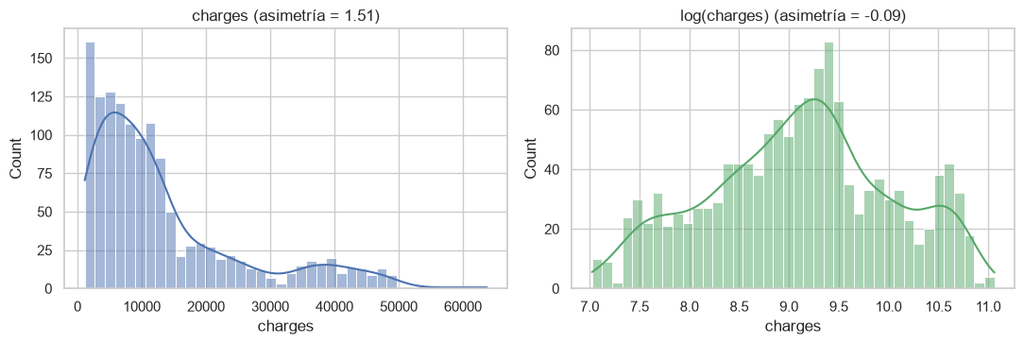

```python
# --- 2.2 Variable objetivo ---
fig, ax = plt.subplots(1, 2, figsize=(11, 3.8))
sns.histplot(df["charges"], bins=40, kde=True, ax=ax[0], color="#4c72b0")
ax[0].set_title(f"charges (asimetría = {stats.skew(df['charges']):.2f})")
sns.histplot(np.log(df["charges"]), bins=40, kde=True, ax=ax[1], color="#55a868")
ax[1].set_title(f"log(charges) (asimetría = {stats.skew(np.log(df['charges'])):.2f})")
plt.tight_layout(); plt.show()
```

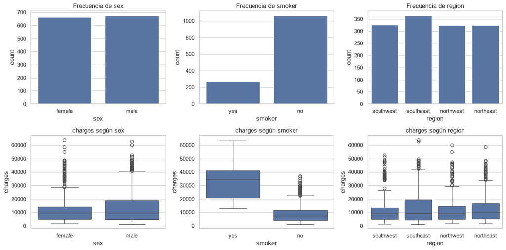

```
Gasto medio por grupo:
```

| smoker | count | mean | median |
| --- | --- | --- | --- |
| no | 1063 | 8,440.66 | 7,345.73 |
| yes | 274 | 32,050.23 | 34,456.35 |

```python
# --- 2.3 Variables categóricas ---
fig, ax = plt.subplots(2, 3, figsize=(14, 7))
for j, col in enumerate(["sex", "smoker", "region"]):
    sns.countplot(data=df, x=col, ax=ax[0, j])
    ax[0, j].set_title(f"Frecuencia de {col}")
    sns.boxplot(data=df, x=col, y="charges", ax=ax[1, j])
    ax[1, j].set_title(f"charges según {col}")
plt.tight_layout(); plt.show()

print("Gasto medio por grupo:")
display(df.groupby("smoker")["charges"].agg(["count", "mean", "median"]))
```

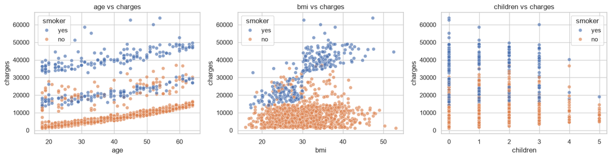

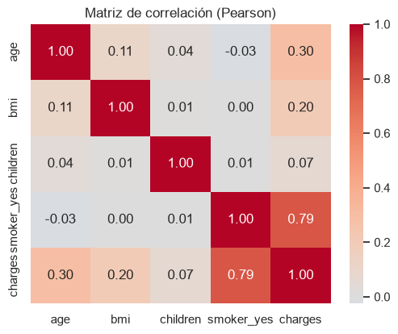

```python
# --- 2.4 Relaciones numéricas ---
fig, ax = plt.subplots(1, 3, figsize=(15, 4))
for a, col in zip(ax, ["age", "bmi", "children"]):
    sns.scatterplot(data=df, x=col, y="charges", hue="smoker", alpha=0.65, ax=a)
    a.set_title(f"{col} vs charges")
plt.tight_layout(); plt.show()

# Correlación (smoker se pasa a 0/1 solo para poder incluirla en la matriz)
corr = df.assign(smoker_yes=(df["smoker"] == "yes").astype(int))[
    ["age", "bmi", "children", "smoker_yes", "charges"]].corr()
plt.figure(figsize=(6, 4.5))
sns.heatmap(corr, annot=True, fmt=".2f", cmap="coolwarm", center=0)
plt.title("Matriz de correlación (Pearson)")
plt.show()
```

**Hallazgos del EDA.**

- **Calidad:** no hay valores nulos y los textos de las categóricas están bien escritos. Se encontró **1 registro duplicado** y se eliminó.
- **`charges` está sesgada a la derecha** (asimetría ≈ 1.5): muchas personas con gasto bajo y una cola larga de gastos altos. Con logaritmo la forma sería casi simétrica, pero se mantiene la escala original para que los coeficientes se lean directamente en dólares.
- **`smoker` es el factor dominante:** los fumadores gastan en promedio unas 4 veces más que los no fumadores y es la variable con mayor correlación con `charges`.
- **`age`** muestra una relación creciente y **`bmi`** aporta más en combinación con ser fumador (se aprecia en el gráfico de dispersión coloreado).
- `sex`, `region` y `children` muestran diferencias pequeñas.

# Fase 3. Detección de valores atípicos (10 %)

**Objetivo.** Identificar observaciones extremas y decidir con criterio si se eliminan, se transforman o se conservan.

**Procedimiento.** Se usa la regla del rango intercuartílico (IQR) de Tukey:

- `Q1` = percentil 25, `Q3` = percentil 75, `IQR = Q3 − Q1`.
- Límite inferior = `Q1 − 1.5·IQR`; límite superior = `Q3 + 1.5·IQR`.
- Todo valor fuera de esos límites se marca como atípico.

Después se revisa quiénes son los atípicos de `charges` (¿errores de captura o casos reales?).

**Justificación.** Eliminar un atípico es válido si es un error; si es un caso real, eliminarlo hace que el modelo ignore justo a las personas más costosas.

```python
def limites_iqr(serie, k=1.5):
    q1, q3 = serie.quantile([0.25, 0.75])
    iqr = q3 - q1
    return q1 - k * iqr, q3 + k * iqr

filas = []
for col in ["age", "bmi", "children", "charges"]:
    inf, sup = limites_iqr(df[col])
    mask = (df[col] < inf) | (df[col] > sup)
    filas.append({"variable": col, "límite inferior": inf, "límite superior": sup,
                  "atípicos": int(mask.sum()), "% del total": mask.mean() * 100})
tabla_outliers = pd.DataFrame(filas).set_index("variable")
tabla_outliers
```

| variable | límite inferior | límite superior | atípicos | % del total |
| --- | --- | --- | --- | --- |
| age | -9.00 | 87.00 | 0 | 0.00 |
| bmi | 13.67 | 47.32 | 9 | 0.67 |
| children | -3.00 | 5.00 | 0 | 0.00 |
| charges | -13,120.72 | 34,524.78 | 139 | 10.40 |

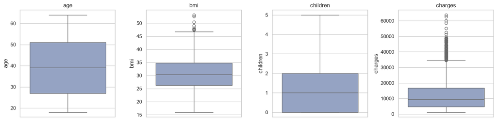

```
charges por encima del límite (34,525): 139
   de ellos, fumadores: 136 (97.8%)

bmi atípicos: 9  (BMI máximo = 53.1, valor extremo pero posible en la práctica)
```

```python
fig, ax = plt.subplots(1, 4, figsize=(15, 3.8))
for a, col in zip(ax, ["age", "bmi", "children", "charges"]):
    sns.boxplot(y=df[col], ax=a, color="#8da0cb")
    a.set_title(col)
plt.tight_layout(); plt.show()

# ¿Quiénes son los atípicos de charges y de bmi?
_, sup_ch = limites_iqr(df["charges"])
altos = df[df["charges"] > sup_ch]
print(f"charges por encima del límite ({sup_ch:,.0f}): {len(altos)}")
print(f"   de ellos, fumadores: {(altos['smoker'] == 'yes').sum()} ({(altos['smoker'] == 'yes').mean():.1%})")

inf_b, sup_b = limites_iqr(df["bmi"])
bmi_out = df[(df["bmi"] < inf_b) | (df["bmi"] > sup_b)]
print(f"\nbmi atípicos: {len(bmi_out)}  (BMI máximo = {bmi_out['bmi'].max():.1f}, valor extremo pero posible en la práctica)")
```

**Decisión: se conservan todos los atípicos.**

- `age` y `children` no tienen atípicos.
- Los atípicos de `bmi` son pocos y corresponden a valores extremos pero **posibles** (no hay BMI negativos ni imposibles).
- Los atípicos de `charges` son casi todos **fumadores**: no son errores de digitación sino el gasto real de ese grupo. Eliminarlos haría que el modelo subestime sistemáticamente a los fumadores, que son justamente los casos más costosos para la organización.

# Fase 4. Preparación de variables (10 %)

**Objetivo.** Dejar los datos listos para el modelo: separar entradas y objetivo, apartar un conjunto de prueba y convertir el texto en números.

**Procedimiento.**

1. **Separar `X` y `y`:** `y = charges` (lo que se quiere predecir) y `X` = las otras seis columnas. `charges` jamás puede quedar en `X`.
2. **Partición 80 % / 20 %** con `train_test_split(test_size=0.2, random_state=42)`. Se usa `stratify=smoker` para que fumadores y no fumadores tengan **la misma proporción** en entrenamiento y prueba (es la variable más influyente y está desbalanceada).
3. **Codificación de categóricas** con `OneHotEncoder(drop="first")`: cada categoría se vuelve una columna 0/1. Se elimina la primera categoría de cada variable para evitar la trampa de la variable ficticia (multicolinealidad perfecta: `smoker_yes` y `smoker_no` darían la misma información y la regresión lineal no podría estimar coeficientes únicos).

**Justificación.** La regresión lineal solo trabaja con números. Se particiona antes de ajustar cualquier transformación para que el conjunto de prueba no influya en nada del entrenamiento.

```python
COLS_NUM = ["age", "bmi", "children"]
COLS_CAT = ["sex", "smoker", "region"]

X = df.drop(columns="charges")
y = df["charges"]

X_train, X_test, y_train, y_test = train_test_split(
    X, y, test_size=0.2, random_state=SEED, stratify=X["smoker"]
)
print(f"X_train: {X_train.shape} | X_test: {X_test.shape}")
print("\nProporción de fumadores:")
print(pd.DataFrame({"train": X_train["smoker"].value_counts(normalize=True),
                    "test": X_test["smoker"].value_counts(normalize=True)}))
```

```
X_train: (1069, 6) | X_test: (268, 6)

Proporción de fumadores:
        train  test
smoker
no       0.80  0.79
yes      0.20  0.21
```

```python
# Demostración de la codificación (ajustada solo con train)
codificador_demo = OneHotEncoder(drop="first", sparse_output=False)
cat_codificadas = codificador_demo.fit_transform(X_train[COLS_CAT])
nombres_cat = codificador_demo.get_feature_names_out(COLS_CAT)

print("Columnas generadas:", list(nombres_cat))
print("Categoría eliminada (referencia) por variable:",
      {c: codificador_demo.categories_[i][0] for i, c in enumerate(COLS_CAT)})
pd.concat([X_train[COLS_CAT].head(4).reset_index(drop=True),
           pd.DataFrame(cat_codificadas[:4], columns=nombres_cat)], axis=1)
```

```
Columnas generadas: ['sex_male', 'smoker_yes', 'region_northwest', 'region_southeast', 'region_southwest']
Categoría eliminada (referencia) por variable: {'sex': 'female', 'smoker': 'no', 'region': 'northeast'}
```

|  | sex | smoker | region | sex_male | smoker_yes | region_northwest | region_southeast | region_southwest |
| --- | --- | --- | --- | --- | --- | --- | --- | --- |
| 0 | female | no | northwest | 0.00 | 0.00 | 1.00 | 0.00 | 0.00 |
| 1 | male | no | southeast | 1.00 | 0.00 | 0.00 | 1.00 | 0.00 |
| 2 | male | no | southeast | 1.00 | 0.00 | 0.00 | 1.00 | 0.00 |
| 3 | male | no | southeast | 1.00 | 0.00 | 0.00 | 1.00 | 0.00 |

**Lectura.** Las 3 variables de texto se convierten en 5 columnas binarias: `sex_male`, `smoker_yes`, `region_northwest`, `region_southeast` y `region_southwest`. Las categorías `female`, `no` y `northeast` quedan como **referencia** (todas las columnas en 0).

# Fase 5. Normalización / estandarización (10 %)

**Objetivo.** Que `age`, `bmi` y `children` tengan escalas comparables.

**Procedimiento.** `StandardScaler` aplica la estandarización *z-score*:

$$ z = \frac{x - \mu}{\sigma} $$

donde `μ` y `σ` son la media y desviación estándar del conjunto de entrenamiento. Cada columna queda con media 0 y desviación 1. Las columnas 0/1 del one-hot no se escalan.

Después se arma el `ColumnTransformer` `preprocesador`, que aplica a cada grupo de columnas su tratamiento:

- **Numéricas:** `SimpleImputer(mean)` → `StandardScaler`.
- **Categóricas:** `SimpleImputer(most_frequent)` → `OneHotEncoder(drop="first")`.

Los imputadores no cambian nada con este archivo (0 nulos), pero hacen que el pipeline no falle si una observación nueva llega con un campo vacío.

**Justificación.** En regresión lineal pura la escala no cambia las predicciones, pero estandarizar permite comparar la magnitud de los coeficientes entre variables, es necesario para medir la importancia con métodos de selección y es buena práctica si luego se pasa a modelos con regularización (Ridge, Lasso).

```python
escalador_demo = StandardScaler().fit(X_train[COLS_NUM])
antes = X_train[COLS_NUM].agg(["mean", "std"]).T
despues = pd.DataFrame(escalador_demo.transform(X_train[COLS_NUM]), columns=COLS_NUM).agg(["mean", "std"]).T
print("ANTES (escala original) vs DESPUÉS (estandarizado):")
display(pd.concat({"antes": antes, "después": despues}, axis=1))
```

```
ANTES (escala original) vs DESPUÉS (estandarizado):
```

|  | antes mean | antes std | después mean | después std |
| --- | --- | --- | --- | --- |
| age | 39.06 | 14.05 | -0.00 | 1.00 |
| bmi | 30.82 | 6.09 | -0.00 | 1.00 |
| children | 1.09 | 1.18 | -0.00 | 1.00 |

```python
preprocesador = ColumnTransformer(transformers=[
    ("num", Pipeline([("imputar", SimpleImputer(strategy="mean")),
                      ("escalar", StandardScaler())]), COLS_NUM),
    ("cat", Pipeline([("imputar", SimpleImputer(strategy="most_frequent")),
                      ("codificar", OneHotEncoder(drop="first", sparse_output=False,
                                                  handle_unknown="ignore"))]), COLS_CAT),
])

X_train_t = preprocesador.fit_transform(X_train)      # aprende SOLO con train
NOMBRES = preprocesador.get_feature_names_out()
print("Matriz transformada:", X_train_t.shape)
print("Columnas:", list(NOMBRES))
```

```
Matriz transformada: (1069, 8)
Columnas: ['num__age', 'num__bmi', 'num__children', 'cat__sex_male', 'cat__smoker_yes', 'cat__region_northwest', 'cat__region_southeast', 'cat__region_southwest']
```

# Fase 6. Selección de atributos (10 %)

**Objetivo.** Saber cuáles variables aportan información real para explicar `charges` y cuáles solo meten ruido.

**Procedimiento.** Se calculan dos puntajes sobre el conjunto de entrenamiento transformado:

- **Estadístico F (`f_regression`)**: mide la relación *lineal* entre cada variable y `charges`; viene con un **p-valor** (si es < 0.05, la relación es estadísticamente significativa).
- **Información mutua (`mutual_info_regression`)**: mide dependencia de cualquier tipo (también no lineal). Sirve como contraste del F.

Luego `SelectKBest(f_regression, k)` conserva las `k` variables de mayor F. El valor de `k` no se escoge a ojo: se decide con validación cruzada en la Fase 7.

**Justificación.** Menos variables irrelevantes significa un modelo más simple, más fácil de explicar y menos propenso a sobreajustar.

|  | variable | F | p-valor | info. mutua | significativa (p<0.05) |
| --- | --- | --- | --- | --- | --- |
| 0 | cat__smoker_yes | 1,632.2 | 0.0000 | 0.361 | sí |
| 1 | num__age | 97.2 | 0.0000 | 1.381 | sí |
| 2 | num__bmi | 35.8 | 0.0000 | 0.105 | sí |
| 3 | num__children | 6.1 | 0.0139 | 0.138 | sí |
| 4 | cat__region_southeast | 5.9 | 0.0151 | 0.020 | sí |
| 5 | cat__region_southwest | 2.6 | 0.1082 | 0.012 | no |
| 6 | cat__sex_male | 1.5 | 0.2260 | 0.139 | no |
| 7 | cat__region_northwest | 0.9 | 0.3497 | 0.043 | no |

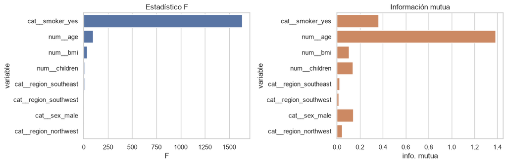

```python
f_vals, p_vals = f_regression(X_train_t, y_train)
mi_vals = mutual_info_regression(X_train_t, y_train, random_state=SEED)

ranking = pd.DataFrame({"variable": NOMBRES, "F": f_vals, "p-valor": p_vals, "info. mutua": mi_vals})
ranking["significativa (p<0.05)"] = np.where(ranking["p-valor"] < 0.05, "sí", "no")
ranking = ranking.sort_values("F", ascending=False).reset_index(drop=True)
display(ranking.style.format({"F": "{:,.1f}", "p-valor": "{:.4f}", "info. mutua": "{:.3f}"}))

fig, ax = plt.subplots(1, 2, figsize=(12, 4))
sns.barplot(data=ranking, y="variable", x="F", ax=ax[0], color="#4c72b0"); ax[0].set_title("Estadístico F")
sns.barplot(data=ranking, y="variable", x="info. mutua", ax=ax[1], color="#dd8452"); ax[1].set_title("Información mutua")
plt.tight_layout(); plt.show()
```

**Lectura.** `smoker_yes` domina con diferencia, seguida de `age` y `bmi`. `children` aporta poco pero es significativa. Entre `sex_male` y las variables de región, solo `region_southeast` llega a ser significativa (p < 0.05) y con un F muy bajo; el resto no lo es. La decisión final de **cuántas** conservar se toma con validación cruzada (Fase 7), no con un corte arbitrario.

# Fase 7. Validación (10 %)

Esta fase tiene dos partes: **(A)** validar que los datos están bien preparados y **(B)** validar el modelo con validación cruzada para elegir `k`.

## 7A. Validación de la integridad de los datos

Se comprueban con `assert` las condiciones que el modelo da por supuestas. Si alguna falla, el notebook se detiene y avisa.

## 7B. Validación cruzada (K-Fold)

**Procedimiento.**

1. Se define el pipeline completo (`preprocesador → SelectKBest → LinearRegression`).
2. `KFold(n_splits=5, shuffle=True)` parte el *train* en 5 bloques. En cada vuelta se entrena con 4 y se mide con el bloque restante.
3. `GridSearchCV` repite esto para `k = 1 … 8` variables y compara el RMSE promedio.
4. Como el pipeline se vuelve a ajustar dentro de cada vuelta, el bloque de validación nunca participa en el escalado, la selección ni el ajuste de la recta: no hay fuga de datos.

**Justificación.** Un solo corte train/test puede dar un resultado bueno o malo por pura suerte. Con 5 cortes se obtiene un promedio y una desviación que indican qué tan estable es el modelo.

```python
# --- 7A. Chequeos de integridad ---
assert df.isna().sum().sum() == 0,                    "Hay valores nulos"
assert df.duplicated().sum() == 0,                    "Hay filas duplicadas"
assert "charges" not in X.columns,                    "charges quedó dentro de X (fuga del objetivo)"
assert df["age"].between(18, 64).all(),               "Edad fuera del rango esperado"
assert (df["bmi"] > 0).all() and (df["charges"] > 0).all(), "Valores no positivos en bmi/charges"
assert set(df["smoker"]) == {"yes", "no"},            "Categorías inesperadas en smoker"
assert set(X_train.index).isdisjoint(X_test.index),   "Hay filas en train y test a la vez"
assert list(X_train.columns) == list(X_test.columns), "train y test tienen columnas distintas"
assert len(X_train) + len(X_test) == len(df),         "Se perdieron filas en la partición"
print("Todos los chequeos de integridad pasaron correctamente.")
```

```
Todos los chequeos de integridad pasaron correctamente.
```

|  | k | RMSE medio | RMSE desv. | R² medio |
| --- | --- | --- | --- | --- |
| 0 | 1 | 7,627.7 | 597.4 | 0.5923 |
| 1 | 2 | 6,598.0 | 694.7 | 0.6967 |
| 2 | 3 | 6,343.9 | 643.3 | 0.7182 |
| 3 | 4 | 6,334.9 | 640.3 | 0.7192 |
| 4 | 5 | 6,309.5 | 654.2 | 0.7215 |
| 5 | 6 | 6,313.7 | 650.6 | 0.7210 |
| 6 | 7 | 6,293.7 | 630.6 | 0.7227 |
| 7 | 8 | 6,297.1 | 628.8 | 0.7224 |

```
Mejor k según validación cruzada: 7
```

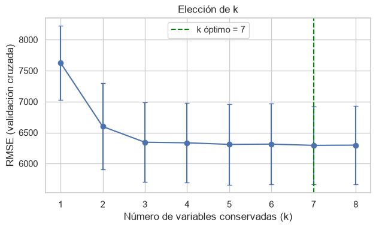

```python
# --- 7B. Validación cruzada y elección de k ---
pipeline_base = Pipeline([
    ("prepro", preprocesador),
    ("seleccion", SelectKBest(score_func=f_regression)),
    ("regresion", LinearRegression()),
])

cv = KFold(n_splits=5, shuffle=True, random_state=SEED)

busqueda = GridSearchCV(
    pipeline_base,
    param_grid={"seleccion__k": list(range(1, len(NOMBRES) + 1))},
    scoring={"rmse": "neg_root_mean_squared_error", "r2": "r2"},
    refit="rmse", cv=cv, return_train_score=False,
)
busqueda.fit(X_train, y_train)

res_k = pd.DataFrame({
    "k": busqueda.cv_results_["param_seleccion__k"].data.astype(int),
    "RMSE medio": -busqueda.cv_results_["mean_test_rmse"],
    "RMSE desv.": busqueda.cv_results_["std_test_rmse"],
    "R² medio": busqueda.cv_results_["mean_test_r2"],
})
display(res_k.style.format({"RMSE medio": "{:,.1f}", "RMSE desv.": "{:,.1f}", "R² medio": "{:.4f}"})
        .highlight_min(subset="RMSE medio", color="#c7e9c0"))

MEJOR_K = int(busqueda.best_params_["seleccion__k"])
print(f"\nMejor k según validación cruzada: {MEJOR_K}")

fig, ax = plt.subplots(figsize=(7, 3.8))
ax.errorbar(res_k["k"], res_k["RMSE medio"], yerr=res_k["RMSE desv."], marker="o", capsize=3)
ax.axvline(MEJOR_K, color="green", ls="--", label=f"k óptimo = {MEJOR_K}")
ax.set_xlabel("Número de variables conservadas (k)"); ax.set_ylabel("RMSE (validación cruzada)")
ax.set_title("Elección de k"); ax.legend(); plt.show()
```

```python
# Métricas de validación cruzada del modelo con el k elegido
pipeline_cv = clone(pipeline_base).set_params(seleccion__k=MEJOR_K)
scores = cross_validate(pipeline_cv, X_train, y_train, cv=cv,
                        scoring={"MAE": "neg_mean_absolute_error",
                                 "RMSE": "neg_root_mean_squared_error",
                                 "R²": "r2"})
resumen_cv = pd.DataFrame({
    "media": [-scores["test_MAE"].mean(), -scores["test_RMSE"].mean(), scores["test_R²"].mean()],
    "desviación": [scores["test_MAE"].std(), scores["test_RMSE"].std(), scores["test_R²"].std()],
}, index=["MAE", "RMSE", "R²"])
resumen_cv
```

|  | media | desviación |
| --- | --- | --- |
| MAE | 4,390.77 | 355.96 |
| RMSE | 6,293.73 | 630.63 |
| R² | 0.72 | 0.04 |

**Lectura.** Con 1 o 2 variables el RMSE es claramente mayor (≈ 7 600 y ≈ 6 600); desde 3 variables el error se estabiliza alrededor de 6 300 y las mejoras posteriores son mínimas: entre `k = 4` y `k = 7` la diferencia es de apenas unos 40 USD, mucho menor que la desviación entre bloques (≈ 630 USD). La validación cruzada eligió `k = 7` por tener el RMSE promedio más bajo, pero la lectura honesta es que **sexo y región prácticamente no aportan**: si se prefiriera el modelo más simple, `k = 4` rendiría casi igual. En ambos casos el R² promedio es ≈ 0.72, con baja variación entre bloques, lo que indica un modelo **estable**.

# Fase 8. Entrenamiento mediante Regresión Lineal (10 %)

**Objetivo.** Ajustar el modelo final y poder explicar qué aprendió.

**Procedimiento.**

1. Se arma el pipeline definitivo con el `k` óptimo y se llama a `fit` con todo el conjunto de entrenamiento.
2. `LinearRegression` encuentra los coeficientes que minimizan la suma de errores al cuadrado (mínimos cuadrados ordinarios):

$$ \widehat{charges} = \beta_0 + \beta_1 x_1 + \beta_2 x_2 + \dots + \beta_k x_k $$

3. Se leen los coeficientes en dos escalas: la estandarizada (para comparar importancia) y la original (para interpretar en dólares por unidad).

**Justificación.** En un modelo lineal los coeficientes son la explicación: cada uno dice cuánto cambia el gasto estimado al mover esa variable, manteniendo las demás constantes.

```python
modelo_final = clone(pipeline_base).set_params(seleccion__k=MEJOR_K)
modelo_final.fit(X_train, y_train)

prepro_ajustado = modelo_final.named_steps["prepro"]
mask = modelo_final.named_steps["seleccion"].get_support()
coefs = modelo_final.named_steps["regresion"].coef_
b0 = modelo_final.named_steps["regresion"].intercept_

escalador = prepro_ajustado.named_transformers_["num"].named_steps["escalar"]
desv = dict(zip(COLS_NUM, escalador.scale_))

filas = []
for nombre, c in zip(prepro_ajustado.get_feature_names_out()[mask], coefs):
    col = nombre.split("__")[1]
    c_orig = c / desv[col] if col in desv else c       # numéricas: se deshace la estandarización
    unidad = {"age": "por cada año", "bmi": "por cada punto de BMI", "children": "por cada hijo"}.get(col, "si la categoría es 'sí'")
    filas.append({"variable": nombre, "coef. estandarizado": c, "efecto en USD": c_orig, "interpretación": unidad})

tabla_coef = pd.DataFrame(filas).sort_values("coef. estandarizado", key=abs, ascending=False)
print(f"Variables que conserva el modelo (k = {MEJOR_K}) | intercepto = {b0:,.2f}")
display(tabla_coef.style.format({"coef. estandarizado": "{:,.2f}", "efecto en USD": "{:,.2f}"}))
```

```
Variables que conserva el modelo (k = 7) | intercepto = 9,106.01
```

|  | variable | coef. estandarizado | efecto en USD | interpretación |
| --- | --- | --- | --- | --- |
| 4 | cat__smoker_yes | 23,753.72 | 23,753.72 | si la categoría es 'sí' |
| 0 | num__age | 3,593.10 | 255.85 | por cada año |
| 1 | num__bmi | 2,015.49 | 331.31 | por cada punto de BMI |
| 5 | cat__region_southeast | -1,017.12 | -1,017.12 | si la categoría es 'sí' |
| 6 | cat__region_southwest | -853.15 | -853.15 | si la categoría es 'sí' |
| 2 | num__children | 735.54 | 622.56 | por cada hijo |
| 3 | cat__sex_male | -260.48 | -260.48 | si la categoría es 'sí' |

**Lectura.** El modelo conserva 7 de las 8 columnas (descarta `region_northwest`). Manteniendo las demás variables constantes:

- **Fumar suma ≈ 23 750 USD** al gasto estimado, con diferencia el efecto más grande.
- **Cada año de edad suma ≈ 256 USD** y **cada punto de BMI ≈ 331 USD**.
- **Cada hijo suma ≈ 623 USD**.
- Vivir en el sureste o suroeste (frente al noreste) y ser hombre (frente a mujer) restan entre 260 y 1 020 USD: efectos pequeños y poco significativos, coherentes con lo visto en el EDA.

El intercepto (≈ 9 106 USD) es la estimación para una mujer no fumadora del noreste/noroeste con la edad, BMI y número de hijos promedio del entrenamiento.

# Fase 9. Evaluación del modelo (10 %)

**Objetivo.** Medir el error del modelo sobre datos que nunca vio (conjunto de prueba) y revisar dónde falla.

**Métricas.**

- **MAE:** error absoluto medio, en USD. Es el error "típico".
- **MSE / RMSE:** el error al cuadrado penaliza más los fallos grandes; el RMSE vuelve a USD.
- **MAPE:** error porcentual medio respecto al valor real.
- **R²:** proporción de la variación de `charges` que explica el modelo (1 = perfecto; 0 = no mejora a predecir siempre el promedio).

Se compara además contra un modelo base (`DummyRegressor`, que siempre predice la media del entrenamiento) para confirmar que el modelo realmente aprende algo.

**Diagnóstico gráfico.** Real vs. predicho y residuos (real − predicho) permiten ver si el error es aleatorio o tiene patrones que el modelo lineal no captura.

```python
y_pred = modelo_final.predict(X_test)

def calcular_metricas(y_real, y_est):
    mse = mean_squared_error(y_real, y_est)
    return {"MAE": mean_absolute_error(y_real, y_est), "MSE": mse, "RMSE": np.sqrt(mse),
            "MAPE (%)": np.mean(np.abs((y_real - y_est) / y_real)) * 100, "R²": r2_score(y_real, y_est)}

base = DummyRegressor(strategy="mean").fit(X_train, y_train)
comparacion = pd.DataFrame({
    "Modelo base (media)": calcular_metricas(y_test, base.predict(X_test)),
    "Regresión lineal (test)": calcular_metricas(y_test, y_pred),
})
display(comparacion)
print(f"R² promedio en validación cruzada (train): {resumen_cv.loc['R²', 'media']:.3f}  |  R² en test: {comparacion.loc['R²', 'Regresión lineal (test)']:.3f}")
```

|  | Modelo base (media) | Regresión lineal (test) |
| --- | --- | --- |
| MAE | 9,080.77 | 3,605.27 |
| MSE | 144,302,357.19 | 25,887,551.84 |
| RMSE | 12,012.59 | 5,087.98 |
| MAPE (%) | 154.10 | 35.06 |
| R² | -0.00 | 0.82 |

```
R² promedio en validación cruzada (train): 0.723  |  R² en test: 0.820
```

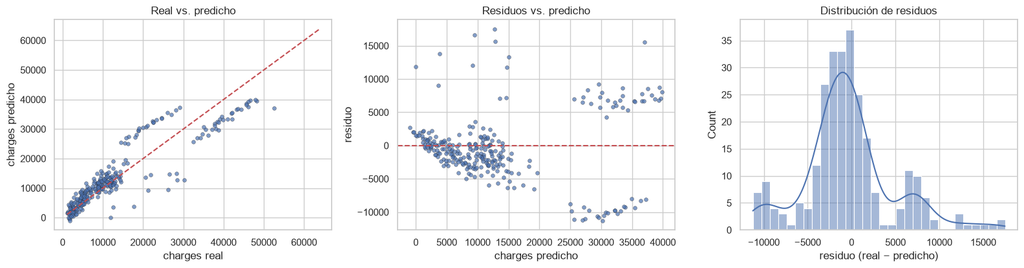

| smoker | personas | gasto_medio | MAE |
| --- | --- | --- | --- |
| no | 213 | 7,931.37 | 2,382.55 |
| yes | 55 | 32,496.62 | 8,340.56 |

```python
residuos = y_test - y_pred
fig, ax = plt.subplots(1, 3, figsize=(16, 4.3))

ax[0].scatter(y_test, y_pred, s=18, alpha=0.7, edgecolor="k", linewidth=0.3)
lim = [y.min(), y.max()]
ax[0].plot(lim, lim, "r--"); ax[0].set_xlabel("charges real"); ax[0].set_ylabel("charges predicho")
ax[0].set_title("Real vs. predicho")

ax[1].scatter(y_pred, residuos, s=18, alpha=0.7, edgecolor="k", linewidth=0.3)
ax[1].axhline(0, color="r", ls="--"); ax[1].set_xlabel("charges predicho"); ax[1].set_ylabel("residuo")
ax[1].set_title("Residuos vs. predicho")

sns.histplot(residuos, bins=30, kde=True, ax=ax[2], color="#4c72b0"); ax[2].set_title("Distribución de residuos"); ax[2].set_xlabel("residuo (real − predicho)")
plt.tight_layout(); plt.show()

# Error por grupo
por_grupo = pd.DataFrame({"smoker": X_test["smoker"], "real": y_test, "pred": y_pred})
por_grupo["error_abs"] = (por_grupo["real"] - por_grupo["pred"]).abs()
display(por_grupo.groupby("smoker").agg(personas=("real", "size"), gasto_medio=("real", "mean"), MAE=("error_abs", "mean")))
```

**Interpretación.**

- **Frente al modelo base:** el modelo explica ≈ 82 % de la variación de `charges` (R² = 0.82) y reduce el error absoluto medio de ≈ 9 081 USD a ≈ 3 605 USD. Hay un aprendizaje real, no un resultado por azar.
- **Sobreajuste:** el desempeño en *test* **no es peor** que en validación cruzada (R² 0.82 contra 0.72), así que no hay sobreajuste. Que sea mejor se debe en parte a que ese bloque de prueba resultó algo más fácil de predecir; por eso conviene reportar ambos valores y no solo el mejor.
- **MAPE ≈ 35 %:** parece alto porque los gastos pequeños (desde ≈ 1 100 USD) inflan el error porcentual; en dólares el error es moderado para la mayoría de personas.
- **Por grupos:** el MAE es ≈ 2 383 USD en no fumadores y ≈ 8 341 USD en fumadores. El modelo falla más justo en el grupo de mayor gasto.

**Límites del modelo lineal.** En el gráfico de residuos se ven agrupaciones y el error crece con el gasto estimado (varianza no constante). Revisando los residuos del *test*, los fumadores con BMI ≥ 30 quedan **subestimados** en promedio ≈ 7 400 USD y los fumadores con BMI < 30 **sobreestimados** ≈ 8 600 USD: el efecto de fumar *depende* del BMI (una interacción) y una recta sin interacciones no puede representarlo. Como mejoras futuras se proponen añadir el término `smoker × bmi`, modelar `log(charges)` o probar modelos no lineales.

# Fase 10. Predicción con nuevos datos (5 %)

**Objetivo.** Usar el modelo como lo usaría la organización: dar los datos de personas nuevas y obtener el gasto estimado.

**Procedimiento.** Se crea un DataFrame con las mismas columnas que `X`. No hay que escalar ni codificar a mano: `predict` recorre el pipeline y aplica lo ya aprendido en el entrenamiento. Se incluye una verificación de que cada persona esté dentro del rango de edad y BMI con el que se entrenó (fuera de ese rango, el modelo extrapola y la estimación es poco confiable).

El tercer y cuarto caso son la misma persona salvo por `smoker`, para aislar cuánto cambia la estimación solo por esa variable.

```python
nuevos = pd.DataFrame([
    {"age": 30, "sex": "female", "bmi": 25.4, "children": 0, "smoker": "no",  "region": "southwest"},
    {"age": 30, "sex": "male",   "bmi": 31.2, "children": 2, "smoker": "yes", "region": "southeast"},
    {"age": 45, "sex": "female", "bmi": 28.0, "children": 1, "smoker": "no",  "region": "northeast"},
    {"age": 45, "sex": "female", "bmi": 28.0, "children": 1, "smoker": "yes", "region": "northeast"},
])

nuevos["charges_estimado"] = modelo_final.predict(nuevos)

# Verificación de rango de entrenamiento
rango_ok = (nuevos["age"].between(X_train["age"].min(), X_train["age"].max()) &
            nuevos["bmi"].between(X_train["bmi"].min(), X_train["bmi"].max()))
nuevos["dentro_del_rango"] = np.where(rango_ok, "sí", "NO")

nuevos.style.format({"charges_estimado": "${:,.2f}"})
```

|  | age | sex | bmi | children | smoker | region | charges_estimado | dentro_del_rango |
| --- | --- | --- | --- | --- | --- | --- | --- | --- |
| 0 | 30 | female | 25.400000 | 0 | no | southwest | $3,458.10 | sí |
| 1 | 30 | male | 31.200000 | 2 | yes | southeast | $29,954.06 | sí |
| 2 | 45 | female | 28.000000 | 1 | no | northeast | $9,632.99 | sí |
| 3 | 45 | female | 28.000000 | 1 | yes | northeast | $33,386.71 | sí |

**Lectura.** Las dos últimas filas son idénticas salvo por `smoker`, y la diferencia entre sus estimaciones es el efecto aislado de fumar según el modelo. Las estimaciones son valores *esperados*, no cifras exactas: el error típico del modelo está dado por el MAE/RMSE de la Fase 9.

# Conclusión

El proyecto permitió recorrer, de principio a fin, el flujo completo de un problema de Machine Learning supervisado: descargar los datos de forma automática, revisar su calidad, decidir con criterio qué hacer con los valores atípicos, preparar y estandarizar las variables, seleccionar atributos, validar con validación cruzada, entrenar una regresión lineal múltiple, evaluarla con datos no vistos y usarla para estimar nuevos casos.

**Resultados principales.**

- El modelo final explica ≈ 82 % de la variación de los gastos médicos en el conjunto de prueba (R² = 0.82), con un error absoluto medio de ≈ 3 605 USD y un RMSE de ≈ 5 088 USD, frente a un MAE de ≈ 9 081 USD de un modelo que siempre predice el promedio.
- **Fumar es, con diferencia, el factor que más pesa:** suma ≈ 23 750 USD al gasto estimado. Le siguen la edad (≈ 256 USD por año), el BMI (≈ 331 USD por punto) y el número de hijos (≈ 623 USD por hijo). El sexo y la región aportan muy poco.
- Los gastos extremos no se eliminaron: casi el 98 % de ellos corresponde a fumadores, así que son casos reales y necesarios para que el modelo aprenda a estimar a quienes más cuestan.

**Limitaciones.** Una recta no capta que el efecto de fumar depende del BMI, por lo que el modelo subestima a los fumadores con BMI alto y sobreestima a los de BMI bajo, y su error es mayor justo en el grupo de mayor gasto. Además, el dataset tiene solo 1 337 registros y un único año, por lo que las estimaciones son orientativas y no deben aplicarse fuera del rango de edad (18–64) y BMI con el que se entrenó.

**Aprendizajes y reflexión.** Lo más valioso fue entender que el orden de las fases importa: particionar *antes* de escalar o seleccionar variables evita la fuga de datos, y encadenar los pasos en un `Pipeline` hace que ese cuidado se cumpla solo, también al validar y al predecir casos nuevos. También aprendí que una métrica sola no basta: el R² del *test* y el de la validación cruzada difirieron, y el análisis de residuos mostró límites que los números globales ocultaban. Como trabajo futuro se propone incluir la interacción `smoker × bmi`, transformar `charges` con logaritmo y comparar con modelos regularizados o de árboles. Esta actividad refuerza la formación en desarrollo de software al mostrar cómo convertir un conjunto de datos en un componente reproducible y explicable que puede integrarse en una aplicación real.

# Bibliografía

Choi, M. (2018). *Medical cost personal datasets* [Conjunto de datos]. Kaggle. https://www.kaggle.com/datasets/mirichoi0218/insurance

Hunter, J. D. (2007). Matplotlib: A 2D graphics environment. *Computing in Science & Engineering, 9*(3), 90–95. https://doi.org/10.1109/MCSE.2007.55

James, G., Witten, D., Hastie, T., & Tibshirani, R. (2021). *An introduction to statistical learning: With applications in R* (2.ª ed.). Springer. https://doi.org/10.1007/978-1-0716-1418-1

Lantz, B. (2013). *Machine learning with R*. Packt Publishing.

McKinney, W. (2010). Data structures for statistical computing in Python. En S. van der Walt & J. Millman (Eds.), *Proceedings of the 9th Python in Science Conference* (pp. 56–61). https://doi.org/10.25080/Majora-92bf1922-00a

Pedregosa, F., Varoquaux, G., Gramfort, A., Michel, V., Thirion, B., Grisel, O., Blondel, M., Prettenhofer, P., Weiss, R., Dubourg, V., Vanderplas, J., Passos, A., Cournapeau, D., Brucher, M., Perrot, M., & Duchesnay, É. (2011). Scikit-learn: Machine learning in Python. *Journal of Machine Learning Research, 12*, 2825–2830.

Tukey, J. W. (1977). *Exploratory data analysis*. Addison-Wesley.

Waskom, M. L. (2021). seaborn: Statistical data visualization. *Journal of Open Source Software, 6*(60), 3021. https://doi.org/10.21105/joss.03021

# Anexos

**Anexo A. Dataset original:** https://www.kaggle.com/datasets/mirichoi0218/insurance

**Anexo B. Cómo reproducir este notebook:**

1. Abrir en Anaconda / Jupyter y ejecutar *Kernel → Restart & Run All*.
2. La Fase 1 descarga el dataset sola con `kagglehub` (si no está instalado, se instala automáticamente).
3. La semilla `SEED = 42` garantiza los mismos resultados en cada ejecución.

**Anexo C. Versiones de las librerías utilizadas:**

```python
import sklearn, matplotlib, scipy
print("Python     :", sys.version.split()[0])
print("pandas     :", pd.__version__)
print("numpy      :", np.__version__)
print("scikit-learn:", sklearn.__version__)
print("matplotlib :", matplotlib.__version__)
print("seaborn    :", sns.__version__)
print("scipy      :", scipy.__version__)
```

```
Python     : 3.11.15
pandas     : 3.0.3
numpy      : 2.4.6
scikit-learn: 1.9.0
matplotlib : 3.11.0
seaborn    : 0.13.2
scipy      : 1.17.1
```